# Préparation CCF E5.2 : DMI

Ce système sera utilisé dans le cadre de l’épreuve de CCF E5.2.

## Présentation

Le système « DMI » (Diffusion de Messages Interactifs) permet un affichage dynamique d’informations sur écran.

Ce système sera composé de plusieurs points d’affichage.

Un point d’affichage (PA) est composé :

- d’un écran (télévision, vidéo) ou d’un bandeau lumineux (en option),
- d’une carte RASPBERRY PI (2 B+ ou 3)
- d’une interface réseau Ethernet filaire ou Wifi.

Tous les PA sont reliés à un serveur. La configuration du système « DMI » est réalisée via un client web.

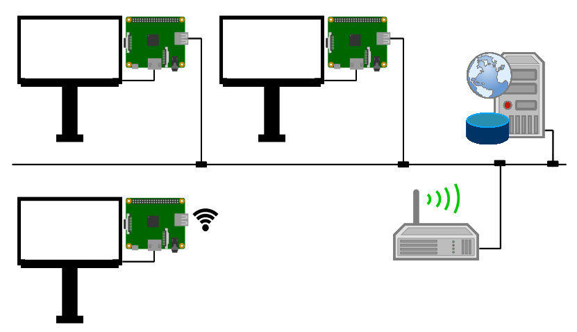

Le serveur héberge :

- un serveur de base de données MySQL ;
- un serveur web et une application (HTML/CSS/PHP).

Après authentification, l’administrateur a la possibilité de gérer les PA à partir de l’application web :

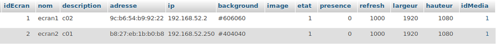

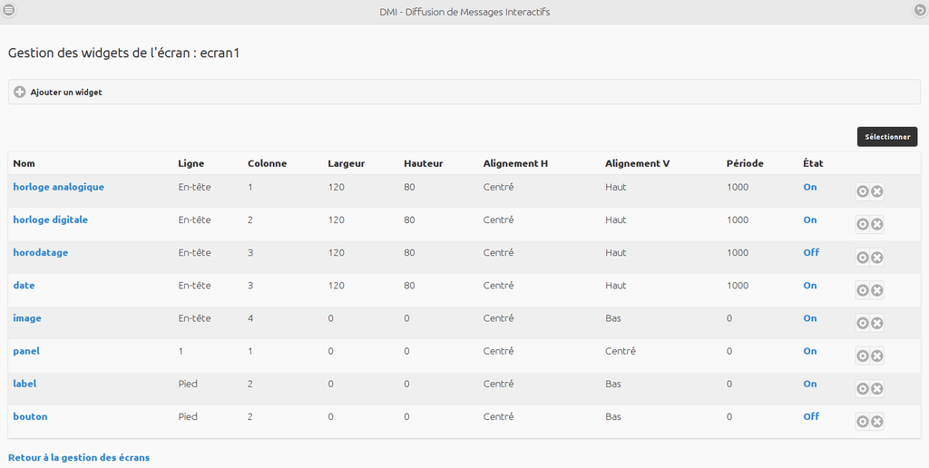

Le diagramme des cas d’utilisation est :

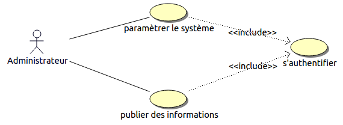

Le PA est construit autour d’un nano ordinateur Raspberry Pi (processeur ARM) sur lequel est installé le système d’exploitation Raspbian (Linux). Il intègre une application Qt de gestion de l’affichage. Une liaison HDMI permet de connecter un écran.

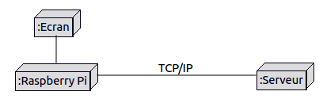

## Contraintes d’environnement

| Ressource | Version |
| --- | --- |
| OS | GNU Linux (Ubuntu 16.04 LTS), Rapsbian |
| API | Qt 5, >= PHP 5 |

## Manuel d’installation Serveur (PC)

0. Exécuter le programme d’installation setup-dmi-www.sh :

```
$ sudo ./setup-dmi-www.sh
```

## Manuel d’installation Raspberry Pi/PC

0. Installer l’application pour Raspberry Pi dmi-rpi.deb :

```
$ sudo dpkg -i ./dmi-rpi.deb
```

*Remarque :* L’installation a assuré la prise en charge du lancement automatique de l’application au démarrage de la Raspberry Pi. Vous pouvez vérifier en réalisant un reboot. Si votre système ne démarre pas automatiquement l’interface graphique, il vous faudra le configurer en suivant ce [guide](http://tvaira.free.fr/projets/activites/activite-autostart.html).

Ou la version pour PC dmi-pc.deb :

```
$ sudo dpkg -i ./dmi-pc.deb
```

*Remarque :* Pour la version PC, il n’y a pas de prise en charge du lancement automatique de l’application, ni de mode *kiosk*.

Pour démarrer la version PC, il suffit d’exécuter le programme :

```
$ DMI
```

L’application gère ses paramètres de configuration à partir d’un fichier `dmi.ini` :

```
[ecran]
nom = test
description = un écran
; couleur de fond
background = #404040
; image de fond
image =
; 1 : on, 0 : off
etat = 1
; en ms
refresh = 1000
; (1 : 'Vidéo', 2 : 'TV')
media = 1

[bd]
hostname = "localhost"
username = "dmi"
password = "password"
database = "dmi"
```

Le fichier `dmi.ini` est stocké dans `/usr/share/dmi/`. Il faudra configurer la section **bd**.

Pour désinstaller le paquet, il suffit de faire :

```
$ sudo dpkg -P dmi-rpi

$ sudo dpkg -P dmi-pc
```

## Serveurs Apache et MySQL

Un pare-feu est installé en configuration `close-config`. L’administration du serveur se fait via **ssh**.

Une tâche *cron* archive les *logs* d’une semaine chaque dimanche à 23h59.

## Manuel d’utilisation

Utiliser un client web (navigateur) et accéder au site web du système DMI.

## Glossaire

- DMI : Diffusion de Messages Interactifs
- PA : Point d’Affichage (écran TV par exemple) équipé d’une Raspberry Pi
- Raspberry Pi : nano-ordinateur monocarte à processeur ARM
- Mode kiosque : Le mode kiosque (ou *kiosk*) a été conçu à l’origine pour les bornes internet (*Internet kiosks*) et il est utilisé ici sur un PA. Il met en place un environnement logiciel restreint aux fonctions essentielles : empêcher les utilisateurs d’utiliser le système, dédier l’affichage graphique exclusivement à l’application et enlever les composants graphiques habituels (curseur souris, barre de titre, tableau de bord, icones, etc …).

## Activités

- Matériels : Raspberry Pi
- Réseau : Ethernet, TCP/IP
- Fichiers : LOG, INI et Base de données
- Serveurs : [Serveur Ubuntu](http://tvaira.free.fr/bts-sn/admin/tp-installation-serveur.pdf), [Serveur Web](http://tvaira.free.fr/bts-sn/admin/tp-installation-http.pdf), [Serveur Base de données](http://tvaira.free.fr/bts-sn/admin/tp-installation-mysql.pdf)
- Autre(s) : [Parefeu](http://tvaira.free.fr/bts-sn/admin/tp-installation-parefeu.pdf), [Utilisateurs](http://tvaira.free.fr/bts-sn/admin/tp-installation-utilisateurs.pdf), [Processus](http://tvaira.free.fr/bts-sn/admin/tp-installation-processus.pdf)

Retour au sommaire